# Assignment 4B

Chen Jianguang Kevin

10/8/2019

# Finding #1

The bank wants to decide how to segment different banking tiers (Retail, Premier, Treasures) based on existing clients’ bank balances. After analysis, the bank sees core concentration of bank balances below $30,000. As such, the bank decided to set Treasures Banking as >$20K, Premier Banking as >$10K and Retail Banking as <=$10K.

```r
bank %>%
 group_by(bal_grp = (balance %/% 1000) * 1000) %>%
 summarise(count = n()) %>%
 arrange(bal_grp) -> banktier
banktier
```

```
## # A tibble: 33 x 2
##    bal_grp count
##      <dbl> <int>
##  1   -4000     1
##  2   -3000     1
##  3   -2000    12
##  4   -1000   352
##  5       0  2674
##  6    1000   594
##  7    2000   268
##  8    3000   186
##  9    4000   124
## 10    5000    75
## # ... with 23 more rows
```

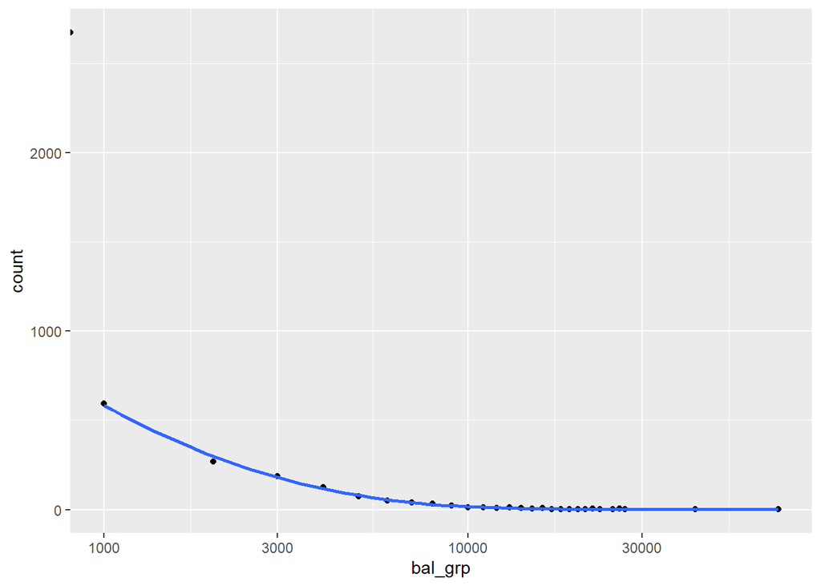

```r
ggplot(banktier, aes(bal_grp, count)) +
  geom_point() +
  geom_smooth(method = "auto", se = F) +
  scale_x_log10()
```

# Finding #2

The bank wants a general snapshot view on the characteristics of the clients in order to start series of advertisments targeting different core groups of clients. The bank wishes to segment the clients into different groups based on education level. Then it wishes to see the distribution of particular age clients of particular occupations would tend to have what amount of bank balances.

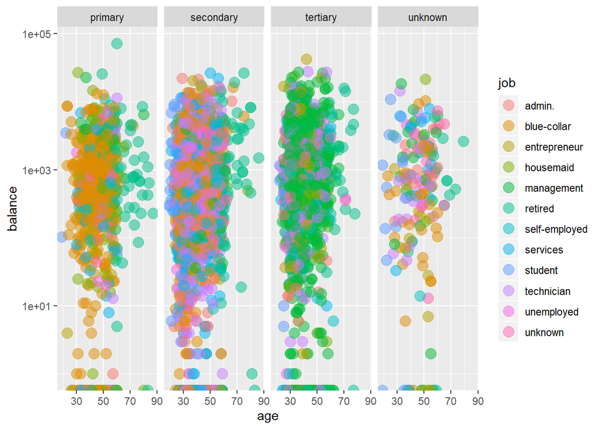

```r
ggplot(bank, aes(age, balance)) +
  geom_point(aes(color=job), size = 4, alpha = 1/2) +
  facet_grid(. ~ education) +
  scale_y_log10()
```

# Finding #3

The bank wants to find out which three jobs poses the highest default risk, so the bank can create more stringent credit checks on loan applications from these individuals in future. After analysis, they are entrepreneurs (4.17%), self-employed (2.19%) and unemployed (2.34%).

```r
bank %>%
 group_by(job) %>%
 summarise(count = n(),
           default_count = sum(ifelse(default == "no", 0, 1)),
           default_perc = default_count * 100 / count) %>%
            arrange(job) -> defaultconc
defaultconc
```

```
## # A tibble: 12 x 4
##    job           count default_count default_perc
##    <fct>         <int>         <dbl>        <dbl>
##  1 admin.          478             6         1.26
##  2 blue-collar     946            14         1.48
##  3 entrepreneur    168             7         4.17
##  4 housemaid       112             2         1.79
##  5 management      969            14         1.44
##  6 retired         230             3         1.30
##  7 self-employed   183             4         2.19
##  8 services        417             7         1.68
##  9 student          84             1         1.19
## 10 technician      768            15         1.95
## 11 unemployed      128             3         2.34
## 12 unknown          38             0         0
```

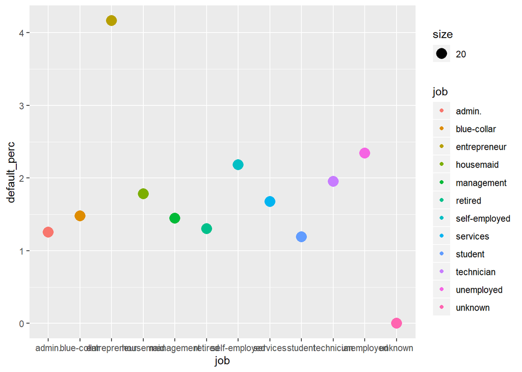

```r
defaultconc %>%
ggplot(aes(x = job, y = default_perc, color = job)) +
  geom_point(aes(size = 20))
```

# Finding #4

The bank wants to find out whether it is feasible to launch a campaign based on marital status and housing loans. In particular, the bank also wants to focus on different marital status and those with houses but no loans.

```r
df1 <- group_by(bank, marital) %>%
  summarise(`With housing` = sum(housing=="yes"))
df2 <- group_by(bank, marital) %>%
  summarise(`Without loan` = sum(loan=="no"))
df3 <- group_by(bank, marital) %>%
  summarise(`With house and no loan` = sum(housing=="yes" & loan=="no"))
df4 <- left_join (df1, df2, by = "marital")
df <- left_join (df4, df3, by = "marital")
df
```

```
## # A tibble: 3 x 4
##   marital  `With housing` `Without loan` `With house and no loan`
##   <fct>             <int>          <int>                    <int>
## 1 divorced            298            438                      253
## 2 married            1625           2344                     1345
## 3 single              636           1048                      555
```

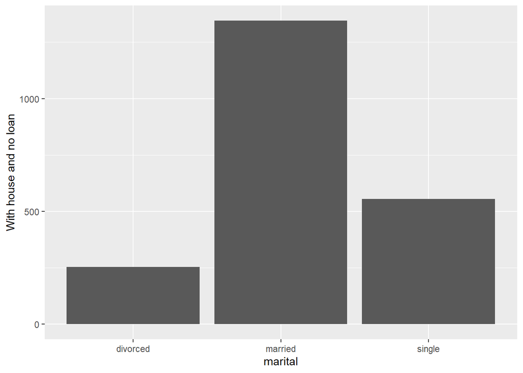

```r
ggplot(df,aes(x = marital, y = `With house and no loan`)) +
  geom_col()
```

# Finding #5

The bank is planning to create a programme to cater to clients with the highest balances. The bank needs to first understand what is the maximum balance for age group and in particular, which occupation, before customizing this programme.

```r
df <- group_by(bank, job) %>%
  filter(balance == max(balance))
df
```

```
## # A tibble: 12 x 17
## # Groups:   job [12]
##      age job   marital education default balance housing loan  contact
##    <int> <fct> <fct>   <fct>     <fct>     <int> <fct>   <fct> <fct>
##  1    28 stud~ single  secondary no        11555 no      no    cellul~
##  2    31 hous~ single  primary   no        26965 no      no    cellul~
##  3    67 blue~ married secondary no        16353 no      no    cellul~
##  4    36 unem~ single  tertiary  no         9019 yes     no    unknown
##  5    43 tech~ single  tertiary  no        27733 yes     no    unknown
##  6    36 mana~ married tertiary  no        27359 yes     no    unknown
##  7    36 self~ married tertiary  no        16430 yes     no    unknown
##  8    42 entr~ married tertiary  no        42045 no      no    cellul~
##  9    50 serv~ married secondary no        26394 no      no    cellul~
## 10    29 admi~ married secondary no        22171 yes     no    cellul~
## 11    60 reti~ married primary   no        71188 no      no    cellul~
## 12    60 unkn~ married unknown   no         7337 no      no    cellul~
## # ... with 8 more variables: day <int>, month <fct>, duration <int>,
## #   campaign <int>, pdays <int>, previous <int>, poutcome <fct>, y <fct>
```

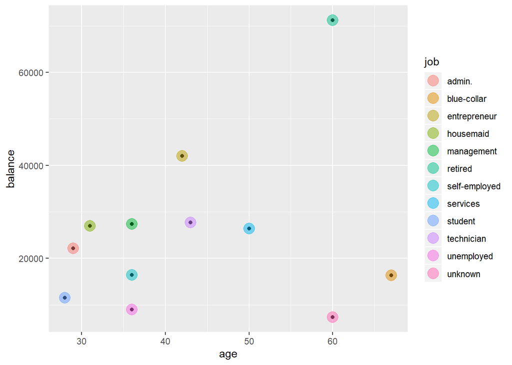

```r
df %>%
ggplot(aes(x = age, y = balance)) +
  geom_point() +
  geom_point(aes(color = job), size = 5, alpha = 1/2)
```

# Finding #6

The bank is thinking of launching a massive bank-wide campaign. It wants to find out which occupation coupled with a particular marital status would have the highest mean balance. The bank also wants to know the median age of a client in such a particular segment so that it can customize its campaign benefits.

```r
bank_summary <- function(frame1) {
  frame1 %>%
    group_by(job, marital) %>%
    summarise(median_of_age = median(age), mean_of_balance = mean(balance)) %>%
    ungroup() %>%
    mutate_if(is.factor, as.character)
}
frame2 <- bank %>%
  bank_summary()
frame3 <- bank %>%
  mutate(marital = "+") %>%
  bank_summary()
frame4 <- bank %>%
  mutate(marital = "+", job = "+") %>%
  bank_summary()
frame5 <- bind_rows(frame2, frame3, frame4)
frame5
```

```
## # A tibble: 48 x 4
##    job          marital  median_of_age mean_of_balance
##    <chr>        <chr>            <dbl>           <dbl>
##  1 admin.       divorced            42            978.
##  2 admin.       married             41           1353.
##  3 admin.       single              33           1111.
##  4 blue-collar  divorced            43            745.
##  5 blue-collar  married             41           1064.
##  6 blue-collar  single              32           1323.
##  7 entrepreneur divorced            49            890.
##  8 entrepreneur married             42           1613.
##  9 entrepreneur single              32           2463.
## 10 housemaid    divorced            50           1166.
## # ... with 38 more rows
```

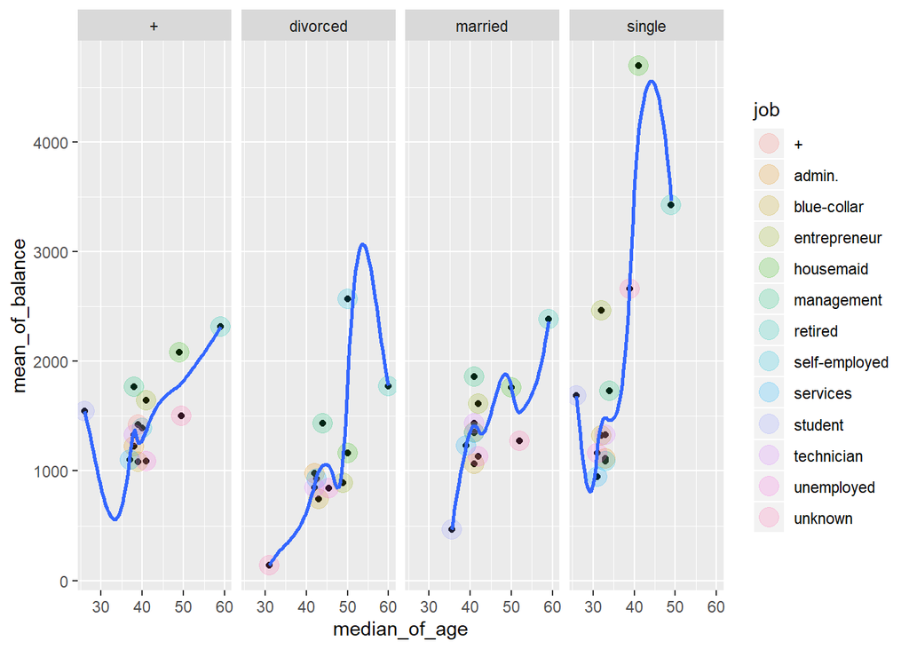

```r
ggplot(frame5, aes(median_of_age, mean_of_balance)) +
  geom_point() +
  geom_point(aes(color=job), size=5, alpha=0.2) +
  geom_smooth(se=F) +
  facet_grid(. ~ marital)
## `geom_smooth()` using method = 'loess' and formula 'y ~ x'
```

# Finding #7

A new CEO just got appointed from DBS Bank. He wants to analyze the education level for clients of different age groups. Then he wants to analyze whether the same distribution ratio holds based on different marital status. The CEO believes this knowledge would give him the necessary information to create investment products targeted at different segments of clients.

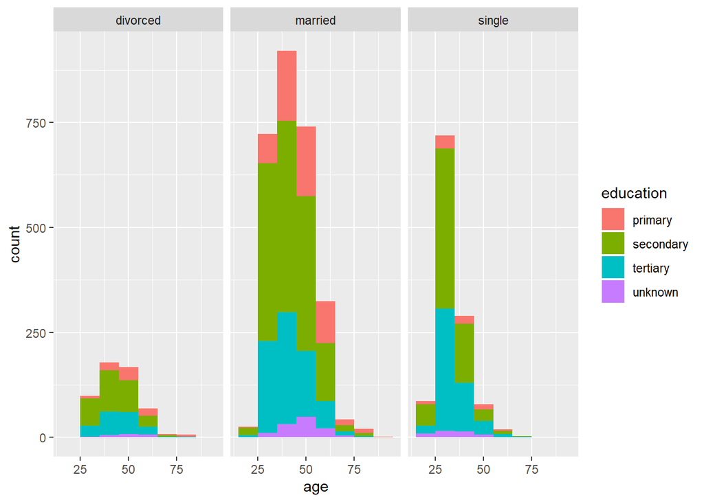

```r
ggplot(bank, aes(age, fill=education)) +
  geom_histogram(binwidth = 10) +
  facet_grid(. ~ marital)
```

# Finding #8

The new CEO next wants to focus on the distribution of marital status within each occupation. He believes this information would let him understand the personal priorities of people within different occupations.

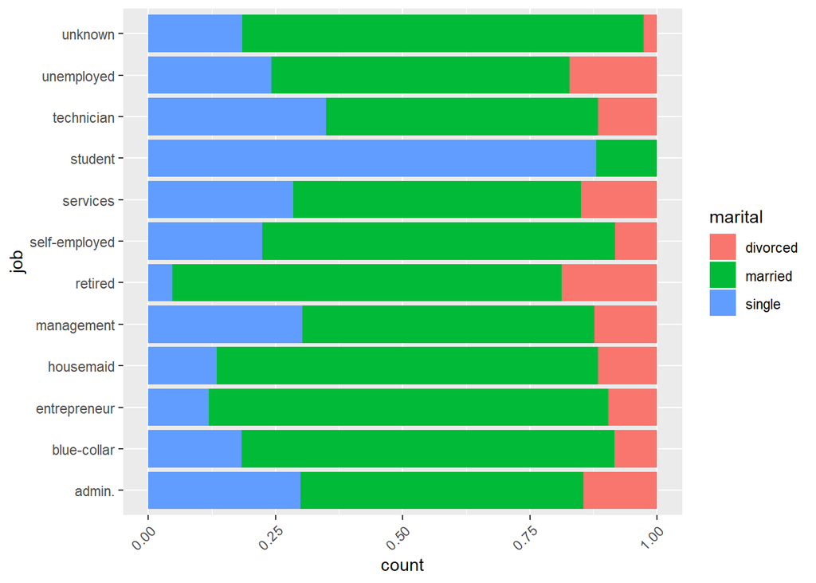

```r
ggplot(bank, aes(x=job, fill=marital)) +
  geom_bar(position = "fill") +
  theme(axis.text.x = element_text(angle = 45, hjust = 1, vjust = 1)) +
  coord_flip()
```

# Finding #9

The new CEO decides to up the ante. He wants to do a serious analysis on bank balances. In particular, the CEO wants a snapshot on bank balance quartile ranges for the different occupations. He is concerned that the educational level of clients may impact his analysis. As such, the CEO wants to split the presentation of results based on different education levels.

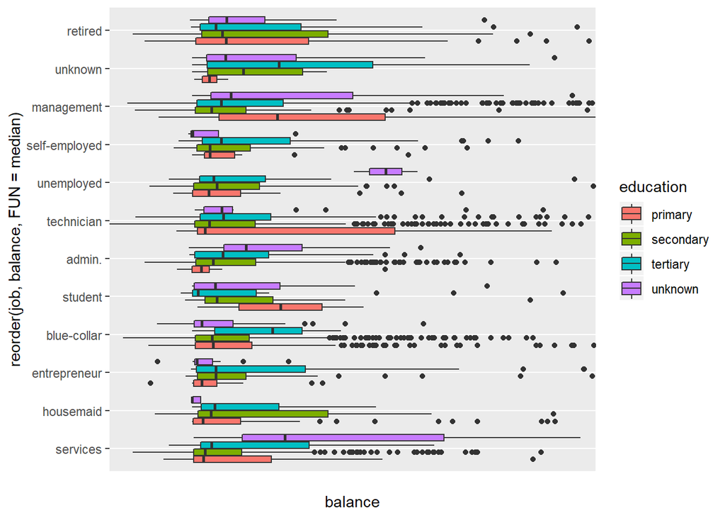

```r
ggplot(bank, aes(x=reorder(job, balance, FUN=median),
                 y=balance, fill=education)) +
  geom_boxplot() +
  scale_y_discrete(limit = 30000) +
  coord_flip()
```

# Finding #10

The new CEO decides that the simpliest and fastest way to generate business results is to run a teleconsulting campaign on clients for bank loans. Either getting a fresh housing loan or for refinancing. The length of the loans offered depends on their age. The possibility of adding additional products to their housing loans depend on their education. The CEO requests a snapshot of these factors.

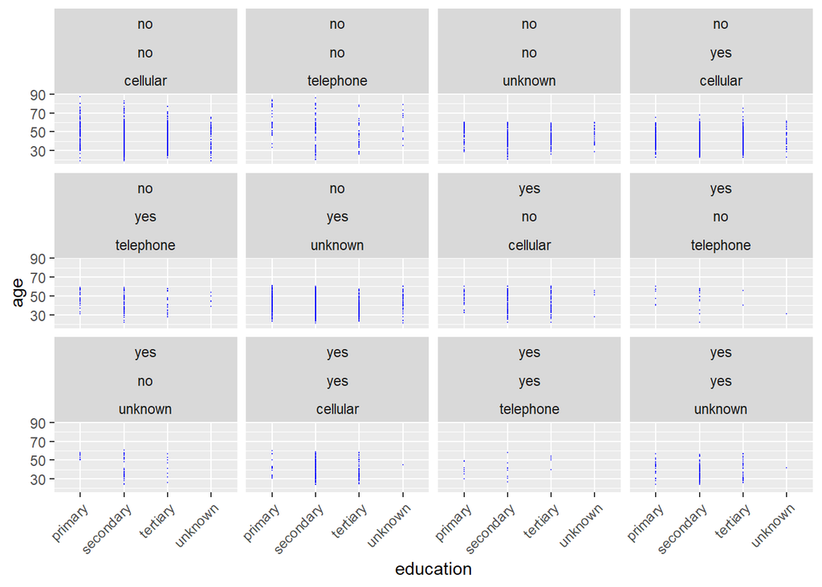

```r
ggplot(bank) +
  geom_point (aes(x=education, y= age), size = 0.1, alpha = 1/2, color = "blue") +
  facet_wrap (loan ~ housing ~ contact) +
  theme (axis.text.x = element_text(angle = 45, hjust = 1, vjust = 1))
```